# GLM para dados discretos

Layla Paiva de Almeida

## 1 Modelo Linear Generalizado para Dados Discretos

Dados discretos são aqueles que se apresentam em números inteiros. São valores que não podem ser quebrados, pois representam unidades, como por exemplo riqueza de espécies. Não se pode ter uma espécie e meia, pois essa medida não é divisível ou separável.

## 2 Na prática

Utilizando os dados disponíveis na pasta `/Dados` da disciplina, escolhi a base de dados `/benthos_exposure.rds`, referente a um estudo sobre a riqueza de espécies da macrofauna bentônica e o impacto da exposição e altura em que os organismos se encontram, em relação ao nível do mar(NAP).

```r
# 1. Importando o banco de dados
dados <- readRDS("~/Disciplinas do Mestrado/ECL0072 - MODELOS LINEARES GENERALIZADOS E ADITIVOS PARA DADOS ECOLÓGICOS/ECL0072-GLM_GAM-gh-pages/ECL0072-GLM_GAM-gh-pages/Dados/benthos_exposure.rds")

#Pacotes
library(ggplot2)
library(dplyr)
library(MASS) #Para rodar modelo Binomial Negativo
library(DHARMa)
library(ggeffects) #para plotar os resultados
library(performance)
```

Portanto a pergunta da nossa análise será: A exposição e NAP influenciam a riqueza de espécies da macrofauna bentônica?

Nesse sentido, a variável dependente (Y) será a riqueza de espécies, sendo nossa variável discreta.

Já as variáveis independentes (X) serão exposição e NAP.

## 3 Análise Exploratória

Agora que tenho a pergunta da análise e os dados, preciso entender como estes se dispõem no arquivo.

```r
# Análise Exploratória
str(dados)
```

```
## 'data.frame':    45 obs. of  5 variables:
##  $ Sample  : int  1 2 3 4 5 6 7 8 9 10 ...
##  $ Richness: int  11 10 13 11 10 8 9 8 19 17 ...
##  $ Exposure: int  10 10 10 10 10 8 8 8 8 8 ...
##  $ NAP     : num  0.045 -1.036 -1.336 0.616 -0.684 ...
##  $ Beach   : int  1 1 1 1 1 2 2 2 2 2 ...
```

```r
summary(dados)
```

```
##      Sample      Richness         Exposure          NAP              Beach
##  Min.   : 1   Min.   : 0.000   Min.   : 8.00   Min.   :-1.3360   Min.   :1
##  1st Qu.:12   1st Qu.: 3.000   1st Qu.:10.00   1st Qu.:-0.3750   1st Qu.:3
##  Median :23   Median : 4.000   Median :10.00   Median : 0.1670   Median :5
##  Mean   :23   Mean   : 5.689   Mean   :10.22   Mean   : 0.3477   Mean   :5
##  3rd Qu.:34   3rd Qu.: 8.000   3rd Qu.:11.00   3rd Qu.: 1.1170   3rd Qu.:7
##  Max.   :45   Max.   :22.000   Max.   :11.00   Max.   : 2.2550   Max.   :9
```

O arquivo possui 45 linhas de dados e 5 variáveis, das quais, a 1° e 5° colunas são referentes à identificação de cada local de amostragem, a coluna 2 e 3 são variáveis discretas e a 4° é a variável NAP, que é uma contínua.

###Convertendo a natureza das variáveis

Classificando as variáveis corretamente:

Mudando a natureza da primeira e ultima coluna para que não sejam interpretadas como numéricas nas análises.

```r
dados$Sample <- as.factor(dados$Sample)
dados$Beach <- as.factor(dados$Beach)

#Verificando a converção:
str(dados)
```

```
## 'data.frame':    45 obs. of  5 variables:
##  $ Sample  : Factor w/ 45 levels "1","2","3","4",..: 1 2 3 4 5 6 7 8 9 10 ...
##  $ Richness: int  11 10 13 11 10 8 9 8 19 17 ...
##  $ Exposure: int  10 10 10 10 10 8 8 8 8 8 ...
##  $ NAP     : num  0.045 -1.036 -1.336 0.616 -0.684 ...
##  $ Beach   : Factor w/ 9 levels "1","2","3","4",..: 1 1 1 1 1 2 2 2 2 2 ...
```

### 3.1 Entendendo as variáveis

Como o banco de dados têm poucas variáveis, podemos explorá-las de forma direta e integral:

```r
dados %>%
  group_by(Richness) %>%
  summarise(NEstacoes = n()) %>%
  mutate(Proporcao = NEstacoes / sum(NEstacoes))
```

```
## # A tibble: 16 × 3
##    Richness NEstacoes Proporcao
##       <int>     <int>     <dbl>
##  1        0         3    0.0667
##  2        1         6    0.133
##  3        2         2    0.0444
##  4        3         8    0.178
##  5        4         5    0.111
##  6        5         3    0.0667
##  7        6         4    0.0889
##  8        7         2    0.0444
##  9        8         2    0.0444
## 10        9         1    0.0222
## 11       10         2    0.0444
## 12       11         3    0.0667
## 13       13         1    0.0222
## 14       17         1    0.0222
## 15       19         1    0.0222
## 16       22         1    0.0222
```

Visualizando a riqueza das estações de amostragem:

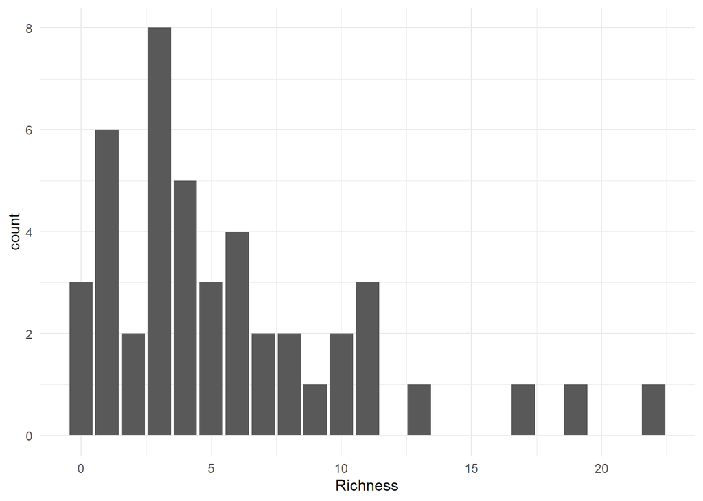

```r
ggplot(dados, aes(Richness, ,group_by(Richness))) +
  geom_bar() +
  theme_minimal()
```

Podemos perceber que a maioria das estaçoes apresentaram até 5 espécies de macrofauna bentônica, um valor baixo considerando que temos algumas amostragens com mais de 15 espécies.

Vamos ver, então, como a riqueza se apresenta dentro dos níveis de exposição das estações

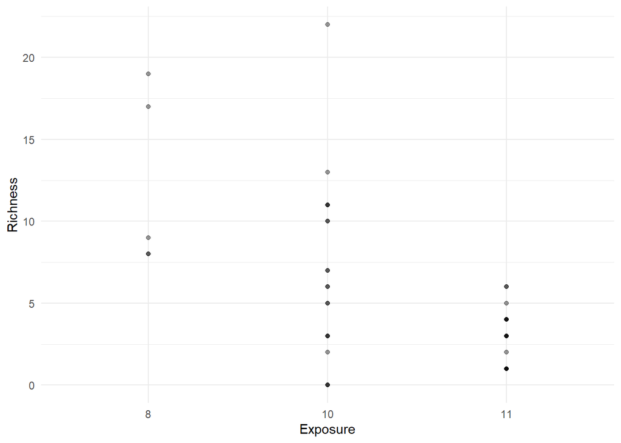

```r
dados$Exposure <- as.factor(dados$Exposure)
dados$Sample <- as.numeric(as.character(dados$Sample))

ggplot(dados, aes(Exposure, Richness)) +
  geom_point(alpha = 0.4) +
  theme_minimal()
```

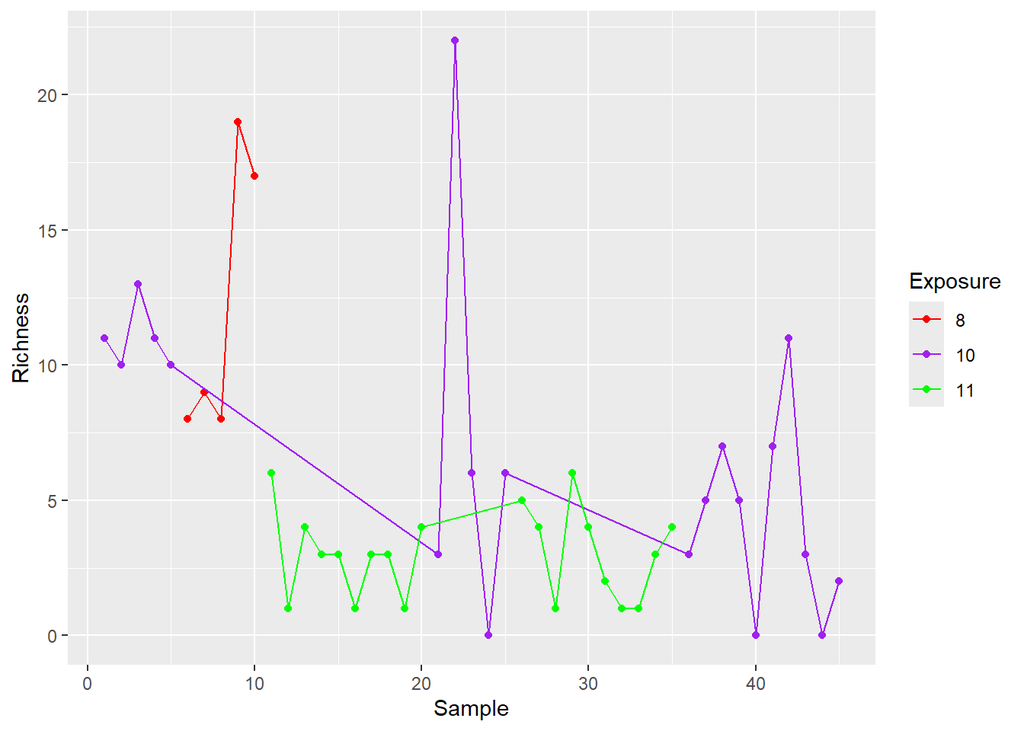

```r
  ggplot(dados, aes(x = Sample, y = Richness, group = as.factor(Exposure), color = Exposure)) +
  geom_point() +
  geom_line() +
  scale_color_manual(values = c("red", "purple", "green"))
```

Vizualizando a riqueza de espécies dentro das NAP

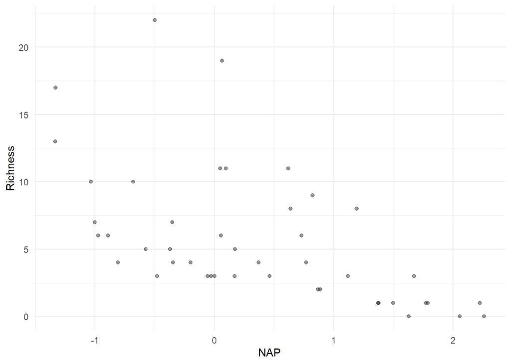

```r
ggplot(dados, aes(NAP, Richness)) +
  geom_point(alpha = 0.4) +
  theme_minimal()
```

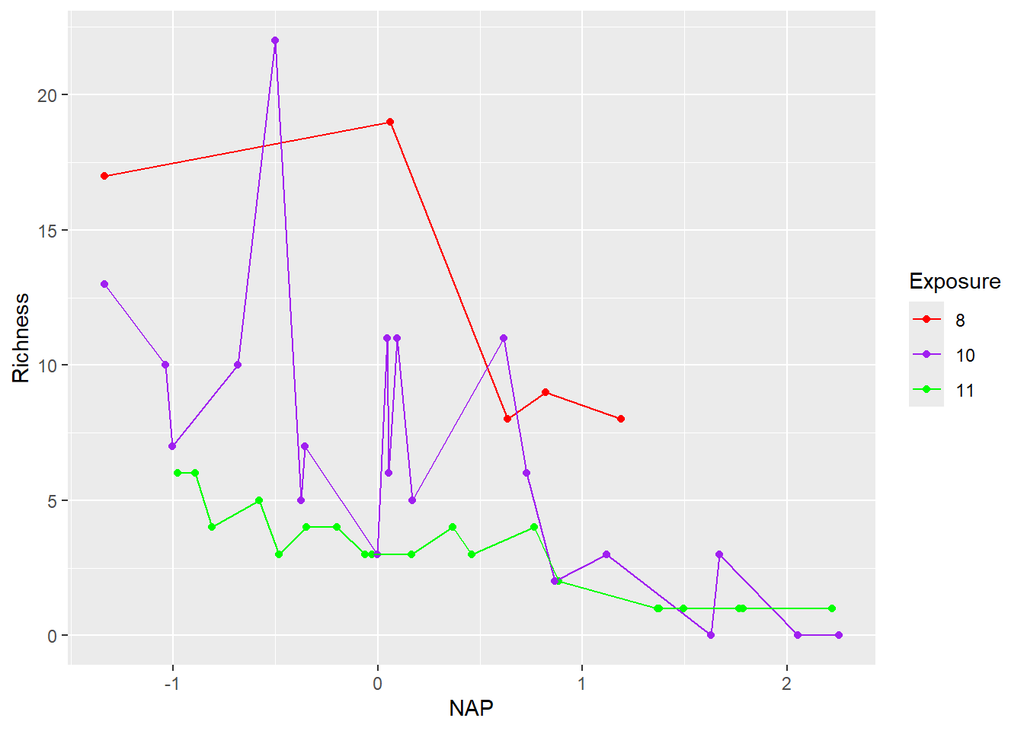

```r
ggplot(dados, aes(x = NAP, y = Richness, group = as.factor(Exposure), color = Exposure)) +
  geom_point() +
  geom_line() +
  scale_color_manual(values = c("red", "purple", "green"))
```

## 4 Hipóteses

Com as análises iniciais, podemos formar nossas hipóteses!

- $H_1:$ O nível de exposição da área de ocorrência influencia a riqueza de espécies locais
- $H_2:$ A altura em que se encontra a área de ocorrência, em relação ao nível do mar, influencia a riqueza de espécies locais

##Objetivos

Avaliar como fatores ambientais, especificamente o nível de exposição e o NAP influenciam a riqueza de espécies locais.

###Objetivos Específicos

1. **Avaliar o efeito do nível de exposição ambiental na riqueza de espécies**
   - Permitirá determinar se a riqueza de espécies difere significativamente entre ambientes mais ou menos expostos a estresses ambientais.
2. **Avaliar a influência da altura, em relação ao nível do mar, da estação amostral na riqueza de espécies**
   - Permitirá avaliar qual limiar de altura esté associado à maior riqueza de espécies.

## 5 Análises & Resultados

Modelo 1

```r
## Modelo 1
mod1 <- glm(Richness ~ Exposure + NAP,
            family = poisson(link = "log"),
            data = dados)


summary(mod1)
```

```
##
## Call:
## glm(formula = Richness ~ Exposure + NAP, family = poisson(link = "log"),
##     data = dados)
##
## Coefficients:
##             Estimate Std. Error z value Pr(>|z|)
## (Intercept)   2.5269     0.1287  19.628  < 2e-16 ***
## Exposure10   -0.5898     0.1543  -3.823 0.000132 ***
## Exposure11   -1.3312     0.1822  -7.305 2.78e-13 ***
## NAP          -0.5137     0.0693  -7.414 1.23e-13 ***
## ---
## Signif. codes:  0 '***' 0.001 '**' 0.01 '*' 0.05 '.' 0.1 ' ' 1
##
## (Dispersion parameter for poisson family taken to be 1)
##
##     Null deviance: 179.753  on 44  degrees of freedom
## Residual deviance:  58.372  on 41  degrees of freedom
## AIC: 208.37
##
## Number of Fisher Scoring iterations: 5
```

```r
#Verificar a dispersão do modelo
mod1$deviance/mod1$df.residual
```

```
## [1] 1.423712
```

O modelo apresenta sobredispersão, uma vez que, phi > 1.

É necessário avaliar outro modelo

Modelo2

```r
#Considerando o esforço amostral
dados$Beach <- as.numeric(as.character(dados$Beach))

mod2 <- glm(Richness ~ Exposure + NAP + offset(log(Beach)),
             data = dados,
             family = "poisson")

summary(mod2)
```

```
##
## Call:
## glm(formula = Richness ~ Exposure + NAP + offset(log(Beach)),
##     family = "poisson", data = dados)
##
## Coefficients:
##             Estimate Std. Error z value Pr(>|z|)
## (Intercept)  1.78625    0.13075  13.661   <2e-16 ***
## Exposure10  -1.48968    0.15576  -9.564   <2e-16 ***
## Exposure11  -2.16643    0.18308 -11.834   <2e-16 ***
## NAP         -0.68419    0.07292  -9.383   <2e-16 ***
## ---
## Signif. codes:  0 '***' 0.001 '**' 0.01 '*' 0.05 '.' 0.1 ' ' 1
##
## (Dispersion parameter for poisson family taken to be 1)
##
##     Null deviance: 430.77  on 44  degrees of freedom
## Residual deviance: 195.63  on 41  degrees of freedom
## AIC: 345.63
##
## Number of Fisher Scoring iterations: 5
```

```r
#Verificar a dispersão do modelo
mod2$deviance/mod2$df.residual
```

```
## [1] 4.77141
```

O modelo 2 também apresenta sobredispersão!

Comparando os modelos

```r
AIC(mod1, mod2) #Comparando
```

```
##      df      AIC
## mod1  4 208.3707
## mod2  4 345.6263
```

Pelo valor de AIC, o modelo 1 se adequa melhor aos dados.

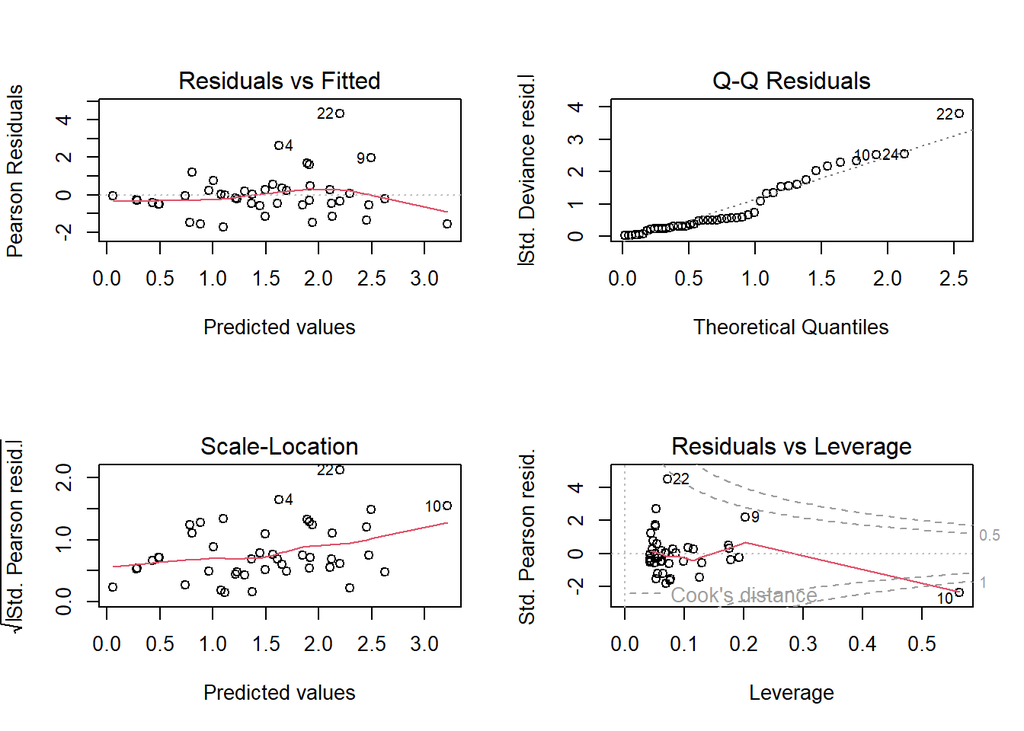

```r
## Rápida inspecção residual
par(mfrow=c(2,2))
plot(mod1)
```

```r
par(mfrow=c(1,1))


check_overdispersion(mod1)
```

```
## # Overdispersion test
##
##        dispersion ratio =  1.410
##   Pearson's Chi-Squared = 57.821
##                 p-value =  0.042
```

```
## Overdispersion detected.
```

Ambos os modelos apresentaram sobre dispersão e não parecem se ajustar bem aos dados.

Testando outros modelos

```r
library(MASS)
mod_nb <- glm.nb(Richness ~ Exposure + NAP, data = dados)
summary(mod_nb)
```

```
##
## Call:
## glm.nb(formula = Richness ~ Exposure + NAP, data = dados, init.theta = 15.25376444,
##     link = log)
##
## Coefficients:
##             Estimate Std. Error z value Pr(>|z|)
## (Intercept)  2.58315    0.17500  14.761  < 2e-16 ***
## Exposure10  -0.65777    0.20503  -3.208  0.00134 **
## Exposure11  -1.38820    0.22636  -6.133 8.64e-10 ***
## NAP         -0.56909    0.08566  -6.644 3.05e-11 ***
## ---
## Signif. codes:  0 '***' 0.001 '**' 0.01 '*' 0.05 '.' 0.1 ' ' 1
##
## (Dispersion parameter for Negative Binomial(15.2538) family taken to be 1)
##
##     Null deviance: 131.279  on 44  degrees of freedom
## Residual deviance:  40.753  on 41  degrees of freedom
## AIC: 206.04
##
## Number of Fisher Scoring iterations: 1
##
##
##               Theta:  15.25
##           Std. Err.:  9.84
##
##  2 x log-likelihood:  -196.041
```

```r
AIC(mod1, mod2, mod_nb)
```

```
##        df      AIC
## mod1    4 208.3707
## mod2    4 345.6263
## mod_nb  5 206.0406
```

O modelo de distribuição binomial negativa apresentou AIC menor, indicando ser melhor ajustada aos dados.

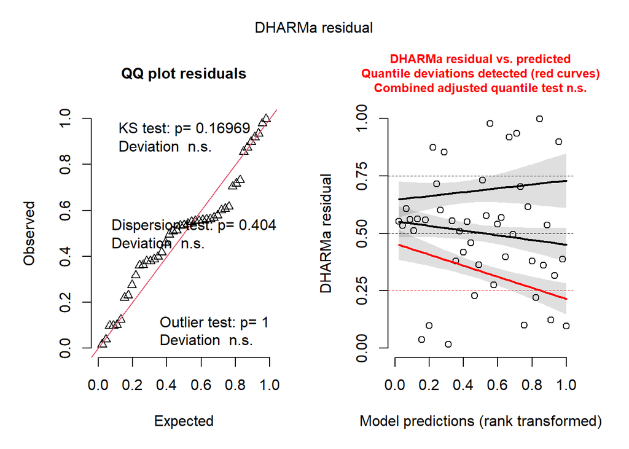

```r
library(DHARMa)

## Simulando os resíduos a partir do modelo escolhido
resid_sim <- simulateResiduals(mod_nb, n=1000)

plot(resid_sim)
```

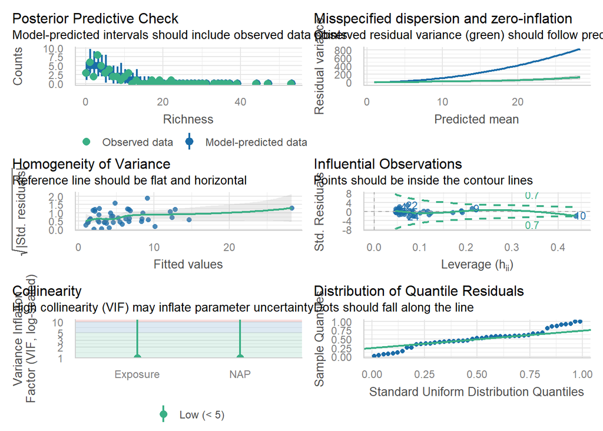

```r
library(performance)
check_model(mod_nb)
```

```r
## Teste de autocorrelação
check_autocorrelation(mod_nb)
```

[output not shown]

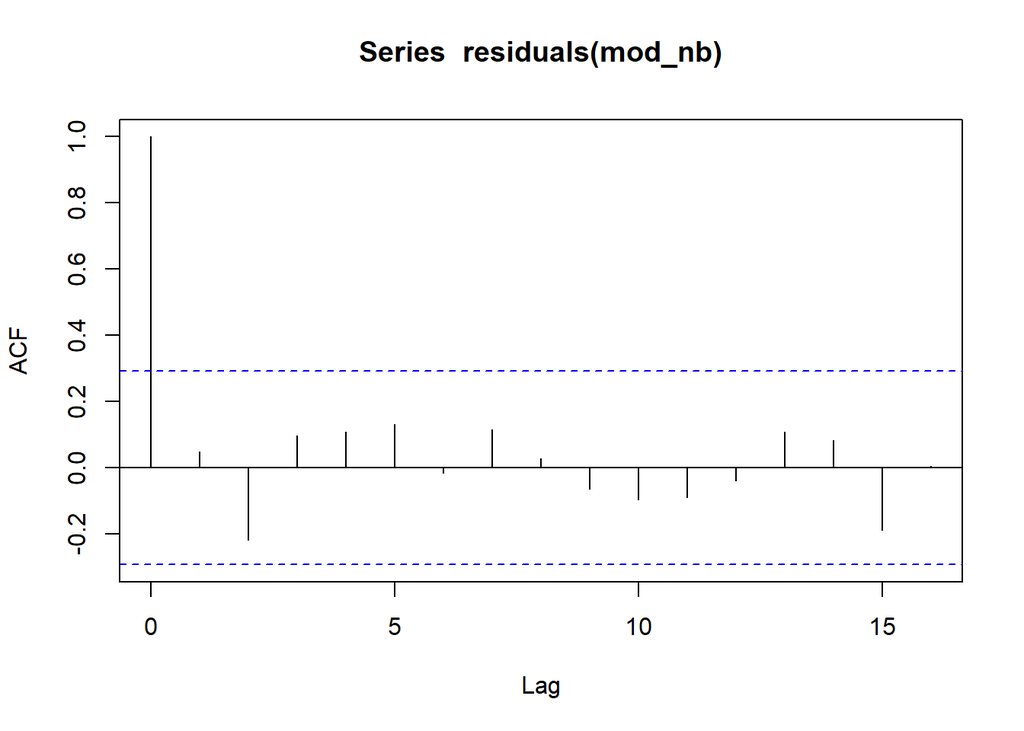

```r
acf(residuals(mod_nb))
```

De modo geral, o novo modelo se ajusta adequadamente aos dados. Tem uma boa distribuição, não apresenta colinearidade, nem resíduos extremos. Os resíduos seguem semelhantes aos valores esperados, mas a variação e homogêniedade não se ajustaram bem.

Analisando as predições

```r
names(mod_nb)
```

```
##  [1] "coefficients"      "residuals"         "fitted.values"
##  [4] "effects"           "R"                 "rank"
##  [7] "qr"                "family"            "linear.predictors"
## [10] "deviance"          "aic"               "null.deviance"
## [13] "iter"              "weights"           "prior.weights"
## [16] "df.residual"       "df.null"           "y"
## [19] "converged"         "boundary"          "terms"
## [22] "call"              "model"             "theta"
## [25] "SE.theta"          "twologlik"         "contrasts"
## [28] "xlevels"           "method"            "control"
```

```r
head(cbind(mod_nb$fitted.values, mod_nb$linear.predictors))
```

```
##        [,1]     [,2]
## 1  6.684330 1.899766
## 2 12.366070 2.514956
## 3 14.668239 2.685685
## 4  4.829841 1.574813
## 5 10.121232 2.314635
## 6  6.725640 1.905927
```

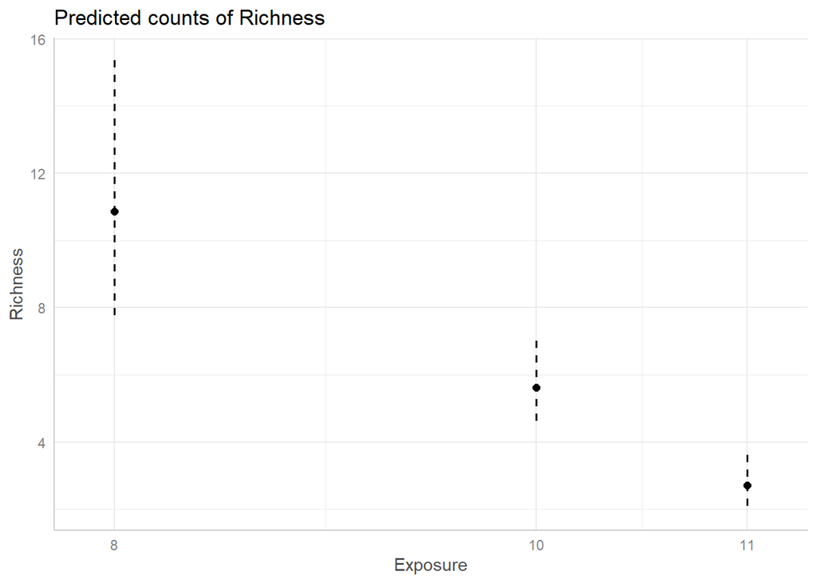

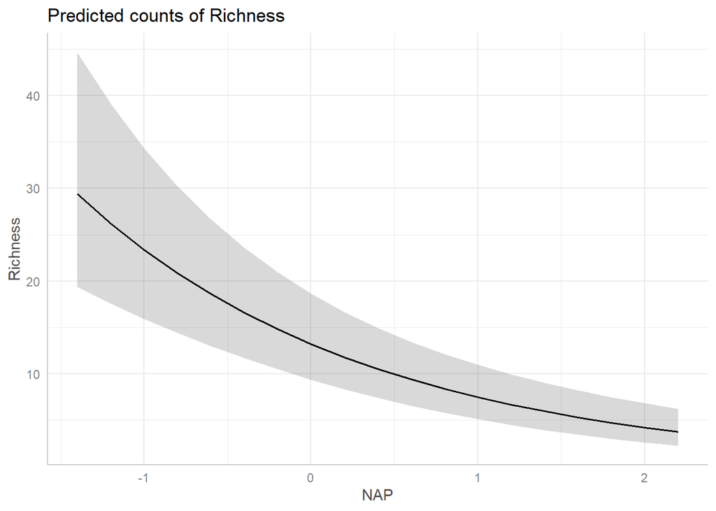

```r
ggpredict(mod_nb) %>% plot()
```

Ambas as variáveis se mostraram significativas. É possível perceber nos gráficos que tanto o nível de exposição, quanto a altura da estação influenciaram a riqueza de espécies. Indicando que sejam negativamente relacionadas, umas vez que com o aumento das variáveis, tem-se a diminuição da riqueza de espécies.

Portanto, as hipóteses foram corroboradas, uma vez que as variáveis apresentaram diferença.